# SEM vs. Mixed

Michael Clark Statistician Lead CSCAR, ARC, U of Michigan

2016-02-13

# Introduction

The following compares a structural equation modeling (SEM) approach with wide format data vs. a mixed model, long-form data approach. In a traditional mixed model we have observations clustered within some group structure, for example, test scores collected over time within students, or survey samples of individuals from each state.

In what follows we can see a traditional mixed model as a form of a constrained latent variable model, where the random effects in the mixed model are represented as a latent variable in the SEM context. This is more explicitly laid out in the area of *growth curve* models, which take a standard setting of a mixed model with longitudinal data in which observations occur over time. However, in the SEM approach we instead take a wide form approach to the data and explicitly model latent variables that reflect the random intercepts and slopes. Growth curve models are highly constrained compared to the usual SEM setting, as most loadings are fixed rather than estimated.

We’ll start by generating some data with the SEM context in mind, then melt it to long form and run a standard mixed model. Following that we’ll compare the two, and eventually add in random slopes.

# Random Intercepts

For the following we start with no additional covariates. In the mixed model framework, a simple random effects model is often depicted as follows:

$$y_{i} = µ + u_{j} + e_{i}$$

In this case, each observation $i$ within a cluster is the result of some overall mean plus a random effect due to belonging to group $j$, plus residual noise.

## Data

In the SEM context, we generate ‘observed’ data $y$ as if there were a single underlying latent variable $f$. Unlike traditional SEM models, here we fix the loading of the latent variable to be 1 for each observed variable. We give the observed $y$ variances of 1, 2 and 3 respectively, and set the ‘fixed effect’ intercept to µ.

```r
set.seed(8675309)
n = 1000
lvI = rnorm(n, sd=2)  # Our latent variable representing random intercepts
mu = .3               # Intercept

### make the data to conform to a mixed model
y1 = mu + 1*lvI + rnorm(n, sd=1)
y2 = mu + 1*lvI + rnorm(n, sd=sqrt(2))
y3 = mu + 1*lvI + rnorm(n, sd=sqrt(3))

y = data.frame(y1, y2, y3)
head(y)
```

```
##           y1        y2         y3
## 1 -1.9605780 0.1515718 -0.1737814
## 2  0.4804558 3.8265794  2.8545217
## 3 -2.1044920 0.7679583 -2.6376176
## 4  5.0600987 1.5849592  2.4593212
## 5  4.0626543 3.5548814  5.7934398
## 6  2.0400965 0.8187298  5.8198780
```

```r
# reshape to long for later use with nlme
library(magrittr); library(dplyr); library(tidyr)
ylong = y
ylong %<>%
  gather(y, key='variable') %>%
  mutate(group = factor(rep(1:n, 3)))
## head(ylong)
##
## # alternative, generate long form first
## group = factor(rep(1:n, 3))
## # y2 = mu + lvI[group] + rnorm(n*3, sd=rep(sqrt(c(1,2,3)), e=n))
## # ylong = data.frame(variable=rep(paste0('y',1:3), e=n), value=y2, group)
## # head(ylong)
```

As we can see and would expect, the variances of the observed variables are equal to the variance of the latent variable (the $u$ random effect in the mixed model) plus the residual variance. In this case 2<sup>2</sup> + c(1, 2, 3).

```r
sapply(y, var)
```

```
##       y1       y2       y3
## 5.349871 6.221397 7.282551
```

## SEM

In this setting the means for the *y* are zero and will be fixed as such.

```r
library(lavaan)
LVmodel1 = '
I =~ 1*y1 + 1*y2 + 1*y3
y1 + y2 + y3 ~ 0*1             # fix y intercepts to zero
'

semres1 = sem(LVmodel1, y)
```

## Mixed Model

For the mixed model we use the melted data with a random effect for group. The nlme package is used because it will allow for heterogeneous variances for the residuals, which is what we need here.

```r
library(nlme)
nlmemod1 = lme(y ~ 1, random= ~ 1|group, data=ylong, weights=varIdent(form = ~1|variable), method='ML')
```

## Model Results and Comparison

### SEM

For the SEM approach we get the results we’d expect, and given the data set size the estimates are right near the true values.

```r
summary(semres1)
```

```
## lavaan (0.5-20) converged normally after  18 iterations
##
##   Number of observations                          1000
##
##   Estimator                                         ML
##   Minimum Function Test Statistic               13.579
##   Degrees of freedom                                 5
##   P-value (Chi-square)                           0.019
##
## Parameter Estimates:
##
##   Information                                 Expected
##   Standard Errors                             Standard
##
## Latent Variables:
##                    Estimate  Std.Err  Z-value  P(>|z|)
##   I =~
##     y1                1.000
##     y2                1.000
##     y3                1.000
##
## Intercepts:
##                    Estimate  Std.Err  Z-value  P(>|z|)
##     y1                0.000
##     y2                0.000
##     y3                0.000
##     I                 0.000
##
## Variances:
##                    Estimate  Std.Err  Z-value  P(>|z|)
##     y1                1.122    0.098   11.420    0.000
##     y2                2.000    0.126   15.912    0.000
##     y3                3.068    0.167   18.353    0.000
##     I                 4.279    0.219   19.550    0.000
```

### Mixed Model

With the mixed model we see the random intercept sd/variance is akin to the latent variable variance, and residual variance is what we’d expect also.

```r
summary(nlmemod1)
```

```
## Linear mixed-effects model fit by maximum likelihood
##  Data: ylong
##        AIC      BIC    logLik
##   12562.33 12592.36 -6276.164
##
## Random effects:
##  Formula: ~1 | group
##         (Intercept) Residual
## StdDev:    2.054055 1.056471
##
## Variance function:
##  Structure: Different standard deviations per stratum
##  Formula: ~1 | variable
##  Parameter estimates:
##       y1       y2       y3
## 1.000000 1.340076 1.658953
## Fixed effects: y ~ 1
##                 Value  Std.Error   DF  t-value p-value
## (Intercept) 0.2466467 0.06929644 2000 3.559299   4e-04
##
## Standardized Within-Group Residuals:
##          Min           Q1          Med           Q3          Max
## -2.582310510 -0.575948827 -0.001671765  0.577319764  2.865939066
##
## Number of Observations: 3000
## Number of Groups: 1000
```

#### Comparison of latent variable and random effects

It’s a little messy to extract the specific individual variance estimates due to the way nlme estimates them[^1], but the estimates of the mixed model and the SEM are the same.

```r
coef(nlmemod1$modelStruct$varStruct, unconstrained =FALSE,allCoef=T)*nlmemod1$sigma
```

```
##       y1       y2       y3
## 1.056471 1.415752 1.752636
```

```r
sqrt(diag(inspect(semres1, 'est')$theta))
```

```
##       y1       y2       y3
## 1.059206 1.414309 1.751525
```

Comparing the latent variable scores to the random effects, we are dealing with almost identical estimates.

```r
comparisonDat = data.frame(LV=lavPredict(semres1)[,1], RE=ranef(nlmemod1)[,1] + fixef(nlmemod1))

head(round(comparisonDat,2), 10)
psych::describe(comparisonDat)
cor(comparisonDat)
```

```
##       LV    RE
## 1  -0.89 -0.86
## 2   1.68  1.70
## 3  -1.21 -1.18
## 4   3.13  3.16
## 5   3.74  3.76
## 6   2.11  2.14
## 7   0.54  0.57
## 8   1.80  1.83
## 9   1.68  1.71
## 10  1.21  1.25
##    vars    n mean   sd median trimmed  mad   min  max range  skew kurtosis   se
## LV    1 1000 0.22 1.93   0.28    0.23 1.92 -6.01 7.17 13.19 -0.08     0.05 0.06
## RE    2 1000 0.25 1.93   0.31    0.26 1.91 -5.97 7.19 13.17 -0.08     0.05 0.06
##           LV        RE
## LV 1.0000000 0.9999993
## RE 0.9999993 1.0000000
```

# Random intercepts and slopes

Now we will investigate random intercepts and slopes as in a standard ‘growth curve model’. For this data the *y* is a repeated measurement over time, otherwise the data is much the same as before. However, we will add a slight positive correlation between intercepts and slopes, and scale time to start at zero so the intercept represents the average baseline value.

## Data

```r
set.seed(8675309)
n = 1000
i = .5
s = .2
f = MASS::mvrnorm(n, mu=c(i,s), Sigma=matrix(c(1,.3,.3,1), nrow=2, byrow=T), empirical=T)
f1 = f[,1]
f2 = f[,2]


### make the data to conform to a mixed model
y1 = 1*f1 + 0*(f2) + rnorm(n, sd=1)
y2 = 1*f1 + 1*(f2) + rnorm(n, sd=sqrt(2))
y3 = 1*f1 + 2*(f2) + rnorm(n, sd=sqrt(3))
y4 = 1*f1 + 3*(f2) + rnorm(n, sd=sqrt(4))

y = data.frame(y1, y2, y3, y4)
head(y)
```

```
##          y1         y2         y3         y4
## 1 0.8233074  0.6094268 -2.9239599 -1.9196902
## 2 2.4320979  0.8722732  0.4130522 -0.6960228
## 3 0.9059002 -2.6873153 -4.6821983 -4.7305664
## 4 0.6309905  2.0462769  4.5094473  6.4255891
## 5 2.6525856  6.4423691  6.0122283  6.2786173
## 6 0.3857095  4.3329025  3.8898125  2.1616358
```

```r
# reshape to long for later use with nlme
ylong = y
ylong %<>%
  gather(y, key='variable') %>%
  mutate(subject = factor(rep(1:n, 4)),
         time = rep(0:3, e=n))
```

Let’s take a look at what we have.

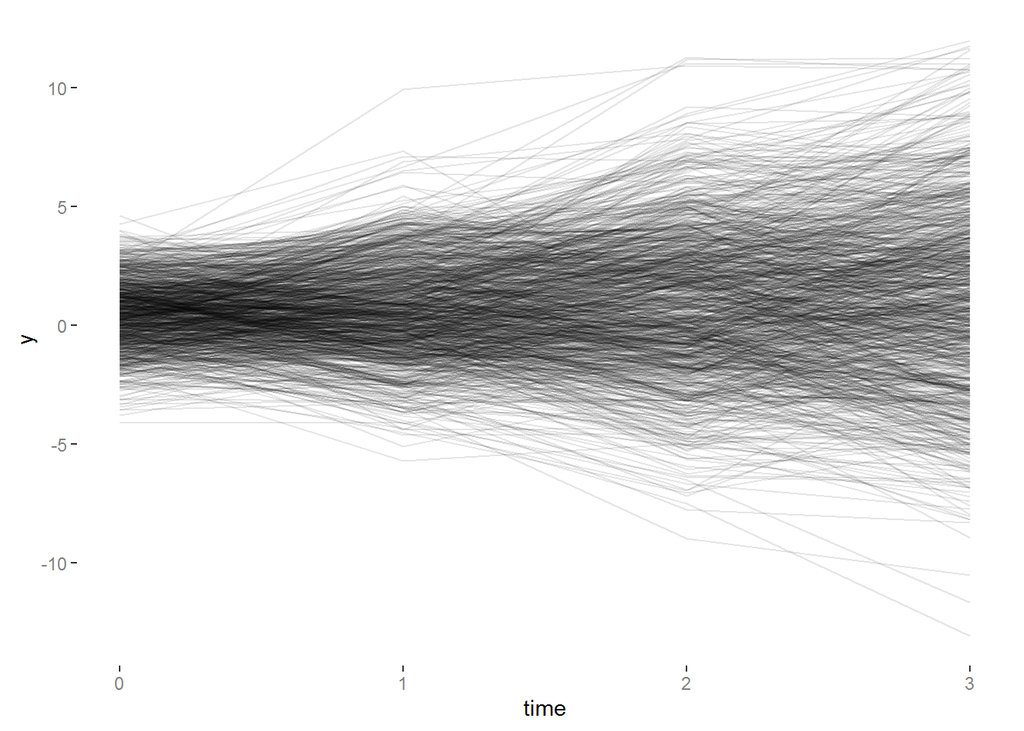

## Models

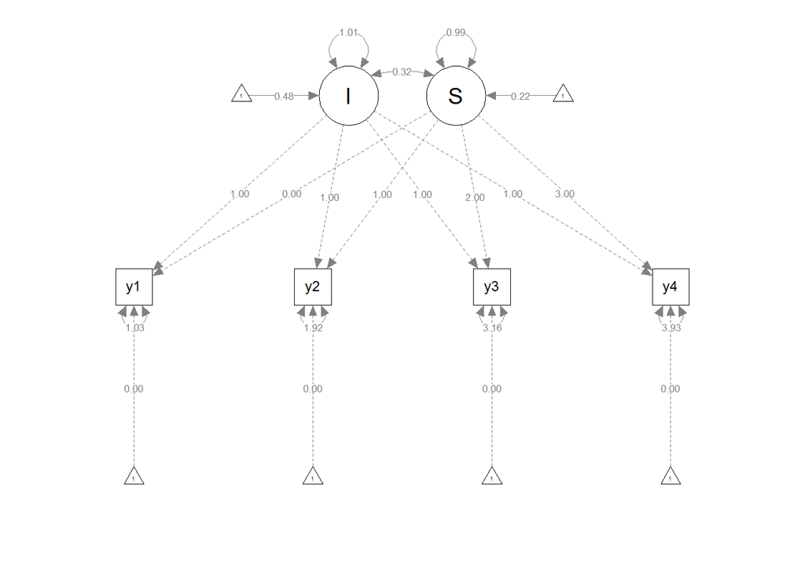

```r
LVmodel2 = '
I =~ 1*y1 + 1*y2 + 1*y3 + 1*y4
S =~ 0*y1 + 1*y2 + 2*y3 + 3*y4
y1 + y2 + y3 +y4 ~ 0*1
'
semres2 = growth(LVmodel2, y)

nlmemod2 = lme(y ~ time, data=ylong, random =  ~time|subject,
              weights=varIdent(form = ~1|variable), method='ML')

semPlot::semPaths(semres2, what='path', whatLabels='est', whatstyle='lisrel')
```

## Model Results and Comparison

### SEM

For the SEM approach we get the results we’d expect, with estimates right near the true values.

```r
summary(semres2)
```

```
## lavaan (0.5-20) converged normally after  28 iterations
##
##   Number of observations                          1000
##
##   Estimator                                         ML
##   Minimum Function Test Statistic                5.918
##   Degrees of freedom                                 5
##   P-value (Chi-square)                           0.314
##
## Parameter Estimates:
##
##   Information                                 Expected
##   Standard Errors                             Standard
##
## Latent Variables:
##                    Estimate  Std.Err  Z-value  P(>|z|)
##   I =~
##     y1                1.000
##     y2                1.000
##     y3                1.000
##     y4                1.000
##   S =~
##     y1                0.000
##     y2                1.000
##     y3                2.000
##     y4                3.000
##
## Covariances:
##                    Estimate  Std.Err  Z-value  P(>|z|)
##   I ~~
##     S                 0.317    0.064    4.931    0.000
##
## Intercepts:
##                    Estimate  Std.Err  Z-value  P(>|z|)
##     y1                0.000
##     y2                0.000
##     y3                0.000
##     y4                0.000
##     I                 0.480    0.043   11.096    0.000
##     S                 0.224    0.038    5.929    0.000
##
## Variances:
##                    Estimate  Std.Err  Z-value  P(>|z|)
##     y1                1.033    0.110    9.411    0.000
##     y2                1.922    0.108   17.809    0.000
##     y3                3.159    0.199   15.840    0.000
##     y4                3.932    0.347   11.323    0.000
##     I                 1.006    0.114    8.849    0.000
##     S                 0.995    0.069   14.364    0.000
```

### Mixed Model

With the mixed model we see the between group sd/variance is akin to the latent variable variance, and residual variance is what we’d expect also.

```r
summary(nlmemod2)
```

```
## Linear mixed-effects model fit by maximum likelihood
##  Data: ylong
##        AIC     BIC    logLik
##   17107.75 17164.4 -8544.875
##
## Random effects:
##  Formula: ~time | subject
##  Structure: General positive-definite, Log-Cholesky parametrization
##             StdDev    Corr
## (Intercept) 1.0031982 (Intr)
## time        0.9973894 0.317
## Residual    1.0161174
##
## Variance function:
##  Structure: Different standard deviations per stratum
##  Formula: ~1 | variable
##  Parameter estimates:
##       y1       y2       y3       y4
## 1.000000 1.364544 1.749243 1.951385
## Fixed effects: y ~ time
##                 Value  Std.Error   DF   t-value p-value
## (Intercept) 0.4797851 0.04324928 2999 11.093483       0
## time        0.2242885 0.03783797 2999  5.927604       0
##  Correlation:
##      (Intr)
## time -0.054
##
## Standardized Within-Group Residuals:
##          Min           Q1          Med           Q3          Max
## -2.668449980 -0.582027043 -0.006143264  0.582212366  3.137291189
##
## Number of Observations: 4000
## Number of Groups: 1000
```

Let’s compare the estimated residual variances again.

```
##                  y1       y2       y3       y4
## varsMixed  1.016117 1.386537 1.777437 1.982836
## varsGrowth 1.016122 1.386542 1.777426 1.982842
```

```
##        I     S X.Intercept.  time
## 1   0.38 -0.68         0.38 -0.68
## 2   1.16 -0.30         1.16 -0.30
## 3  -0.14 -1.48        -0.14 -1.48
## 4   0.93  1.43         0.93  1.43
## 5   2.32  1.62         2.32  1.62
## 6   1.08  0.92         1.08  0.92
## 7   0.63  1.01         0.63  1.01
## 8   1.40  1.76         1.40  1.76
## 9   1.27  0.43         1.27  0.43
## 10  0.33  0.82         0.33  0.82
##              vars    n mean   sd median trimmed  mad   min  max range  skew kurtosis   se
## I               1 1000 0.48 0.80   0.49    0.48 0.79 -2.21 2.96  5.18 -0.08    -0.06 0.03
## S               2 1000 0.22 0.88   0.25    0.21 0.89 -2.83 3.04  5.87  0.08     0.06 0.03
## X.Intercept.    3 1000 0.48 0.80   0.49    0.48 0.79 -2.21 2.96  5.18 -0.08    -0.06 0.03
## time            4 1000 0.22 0.88   0.25    0.21 0.89 -2.83 3.04  5.87  0.08     0.06 0.03
##              I X.Intercept.
## I            1            1
## X.Intercept. 1            1
##      S time
## S    1    1
## time 1    1
```

# Which to use?

It really depends on the model specifics as to which might be best for your situation but I would suggest defaulting to mixed models for a variety of reasons.

- Ease of implementation: Only very little of special syntax is needed for a mixed model approach relative to standard linear model code. Whereas all SEM programs or packages require special syntax.
- Ease of interpretation/communication: Mixed models are far more commonly used across disciplines, and allow the less familiar to use their standard regression knowledge to interpret them in a straightforward fashion. I’ve often seen people that would have no trouble interpreting the mixed model (at least the fixed effects portion), but get hung up on growth models with additional covariates.
- Time-varying covariates: With time-varying covariates, I don’t think people are usually interested in the multivariate approach where each time point of the dependent variable must be predicted by each time point of the covariate, and the model gets unwieldy very quickly with only handful of time-varying covariates. With many time points, the coding and output is also messy with the SEM approach.
- Nonlinear relationships: While one can incorporate nonlinear relationships very easily in the standard setting due to the close ties between mixed and additive models, it becomes cumbersome (adding a quadratic slope factor) or unusual to interpret (allowing the slope loadings to be estimated, rather than fixed) in the SEM setting.
- Correlated residuals: In growth model settings it’s common to specify autocorrelated residuals based on time. The syntax to do so in the SEM framework is very tedious.
- Parallel Processes: Within the Bayesian framework one can incorporate [parallel processes] (multivariate mixed models) via a multivariate outcome fairly easily with the [brms package](https://github.com/paul-buerkner/brms) ([example](https://github.com/mclark--/MultivariateMultiLevelModeling/blob/master/multivariate.knit.md) with Stan).
- Indirect Effects: Indirect effects can also be incorporated in the standard mixed model framework ([example with Stan](https://github.com/mclark--/Miscellaneous-R-Code/blob/master/ModelFitting/Bayesian/rstan_multilevelMediation.R), see also the mediation package for using lme4 for multilevel mediation).
- Sample sizes: SEM is an inherently large sample technique, and growth curve models can quite complicated in terms of the number of parameters to be estimated. Obviously large samples are always desirable for either approach, but e.g. where mixed models can be run on clustered data with 30 clusters, it would be a bit odd to use SEM for 30 observations.
- Balanced data: Growth curve modeling requires balanced data across all time points, and so missing data necessarily has to be estimated or one will potentially lose too much of it. Mixed models do not, but whether one should still estimate the missing values is a matter of debate.

In short, my opinion is that growth curve models would only be preferred in settings where the model is notably complicated, but the level of complexity would start at the point where the interpretation of such a model would already be very difficult. SEM has its place, but the standard mixed model approach should be preferred, even in fairly complicated settings, both for ease of implementation and ease of interpretation.

# Summary

As has been demonstrated, we can think of random effects in mixed models as latent variables, and conversely, we can specify most growth models as standard mixed models. Noting the connection may provide additional insight into how to think about random effects ways in which to incorporate their use in modeling.